# Lab 6 Notes

#### Simple Linear Regression Inference and Diagnostics

Topics: -Residual Properties -Model Inference -T tests -Confidence INtervals

#### Residual Properties

Used to determine if we meet the assumptions on residuals

```r
fit = lm(Sepal.Length~Sepal.Width, data = iris, subset = Species=="setosa")
summary(fit)
```

```
Call:
lm(formula = Sepal.Length ~ Sepal.Width, data = iris, subset = Species ==
    "setosa")

Residuals:
     Min       1Q   Median       3Q      Max
-0.52476 -0.16286  0.02166  0.13833  0.44428

Coefficients:
            Estimate Std. Error t value Pr(>|t|)
(Intercept)   2.6390     0.3100   8.513 3.74e-11 ***
Sepal.Width   0.6905     0.0899   7.681 6.71e-10 ***
---
Signif. codes:  0 ‘***’ 0.001 ‘**’ 0.01 ‘*’ 0.05 ‘.’ 0.1 ‘ ’ 1

Residual standard error: 0.2385 on 48 degrees of freedom
Multiple R-squared:  0.5514,    Adjusted R-squared:  0.542
F-statistic: 58.99 on 1 and 48 DF,  p-value: 6.71e-10
```

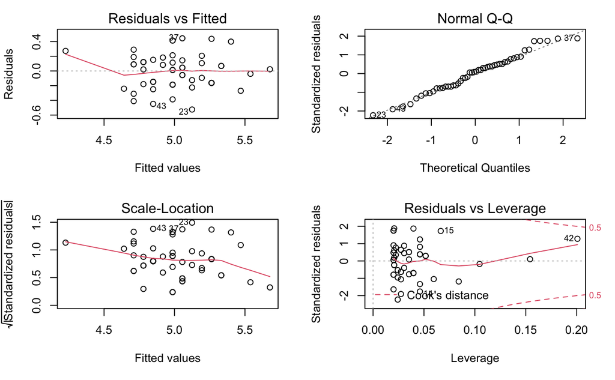

```r
par(mfrow = c(2,2))
plot(fit)
```

-Residual Vs Fitted: Cloudy shape and a straight/flat line -QQ: want to fit the diagonal line to check for normality -Scale-Location: Cloudy shape and a straight/flat line -Leverage Plot: Influential points. Measured by cook’s distance. Points outside of cook’s distance chave a strong influence, leaving them out may result in a different estimate

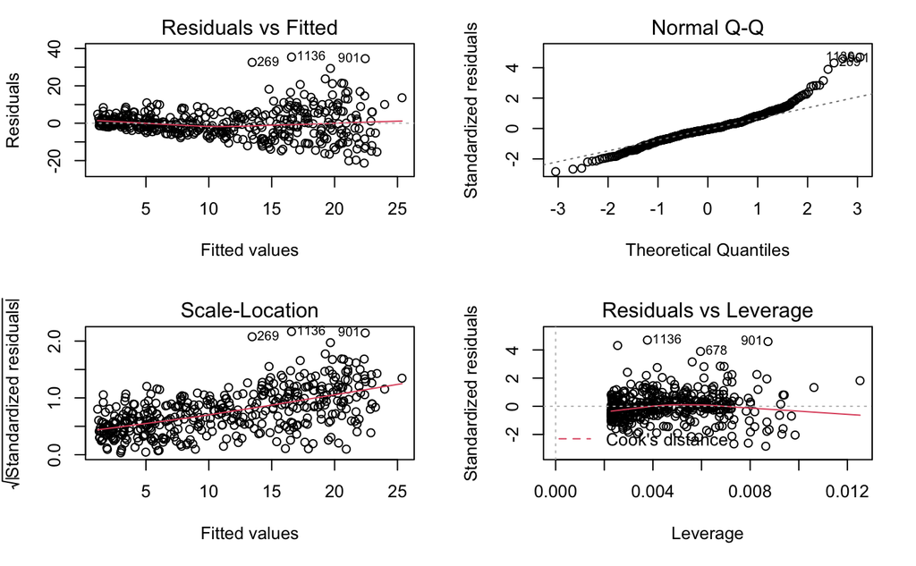

```r
library(UsingR)
fit2 = lm(HR~AB, data = batting)
par(mfrow = c(2,2))
plot(fit2)
```

We do not like “trumpet’ shaped plots.

#### Model Inference

Testing hypotheses on model parameters

Coefficient Standard Errors:

```r
summary(fit)
```

```
Call:
lm(formula = Sepal.Length ~ Sepal.Width, data = iris, subset = Species ==
    "setosa")

Residuals:
     Min       1Q   Median       3Q      Max
-0.52476 -0.16286  0.02166  0.13833  0.44428

Coefficients:
            Estimate Std. Error t value Pr(>|t|)
(Intercept)   2.6390     0.3100   8.513 3.74e-11 ***
Sepal.Width   0.6905     0.0899   7.681 6.71e-10 ***
---
Signif. codes:  0 ‘***’ 0.001 ‘**’ 0.01 ‘*’ 0.05 ‘.’ 0.1 ‘ ’ 1

Residual standard error: 0.2385 on 48 degrees of freedom
Multiple R-squared:  0.5514,    Adjusted R-squared:  0.542
F-statistic: 58.99 on 1 and 48 DF,  p-value: 6.71e-10
```

We can convert to correlations if we wish:

```r
cov2cor(vcov(fit))
```

```
            (Intercept) Sepal.Width
(Intercept)   1.0000000  -0.9940617
Sepal.Width  -0.9940617   1.0000000
```

High values mean that the intercept and the slope are highly negatively correlated

Function for getting standard errors

```r
coef_stdErrors = function(...){
   sqrt(diag(vcov(...)))
}
```

#### T tests

We can do t tests on model coefficients. That is,

$$H_0: \beta_j = \beta_{j0}$$
and

$$H_A: \begin{cases}
\beta_j < \beta_{j0}\\
\beta_j \neq \beta_{j0}\\
\beta_j > \beta_{j0}
\end{cases}$$

Assume that the standard errors $\epsilon_i$ in the regression model are i.i.d and Normally distributed with mean zero. Then we can decide between $H_0$ and $H_A$ using the t-statistic:
$$t = \frac{\hat{\beta_j} - \beta_{k0}}{SE(\hat{\beta_j})}$$
Function for t-statistics:

```r
coef_tstat = function(fit, beta0=0){
   se = coef_stdErrors(fit)
   beta = coef(fit)
   (beta - beta0) / se
}

coef_tstat(fit)
```

```
(Intercept) Sepal.Width
   8.512514    7.680738
```

```r
coef_tstat(fit, beta0 = c(2,1))
```

```
(Intercept) Sepal.Width
   2.061199   -3.442871
```

Function to compute degrees of freedom:

```r
deg_free = function(fit){
   n = length(resid(fit))
   k = length(coef(fit))
   n - k
}

deg_free(fit)
```

```
[1] 48
```

Find p-values using pt function

```r
pt(coef_tstat(fit, beta0 = 0)[1], df = deg_free(fit), lower.tail = FALSE)
```

```
 (Intercept)
1.871219e-11
```

#### Confidence Intervals

##### Margial CIs, use the regular formula:

In mean models we compute CIs for the mean. We would like to compute CIs for the population model coeffiecients as well. However, since were estimating multiple parameters we must take a slightly different approach

We could just consider an interval for each $\beta_j$ without converning ourselves with the values of other coefficients. If we wanted a CI for just $\beta_j$ we could just use
$$\hat{\beta_j} \pm t*SE(\hat{\beta_j})$$
, with t* being the corresponding critical value fro a t dist with n-k-1 degrees of freedom.

```r
install.packages(ellipse)
```

```
Error in install.packages : object 'ellipse' not found
```

#### $R^2$

can extract from model simply with

```r
summary(fit)$r.squared
```

```
[1] 0.5513756
```

R^2 is .55 which tells us we are explaining ~55% of the data with our linear model

Adjusted R^2 penalizes for more predictors.

#### F-Test

used to determine if additional coefficients ‘add value’ to the model.

```r
summary(fit)$fstatistic
```

```
   value    numdf    dendf
58.99373  1.00000 48.00000
```

```r
#Function for getting p value of the f statistic
ftest_pval = function(fit){
   f = summary(fit)$fstatistic
   pf(f[["value"]], df1 = f[["numdf"]], df2 = f[["dendf"]], lower.tail = FALSE)
}

ftest_pval(fit)
```

```
[1] 6.709843e-10
```

#### Point-Wise Inference

-What is the expected value of Y given X? That is, what is the conditional mean of Y when X = x? -If we know X = x, what are the plausible values of Y?

We can use the predict() function on a lm object

```r
predict_func = function(fit){
   response = names(fit$model)[[1]]
   explanatory = names(fit$model)[[2]]
   function(x, ...){
      dat = data.frame(x)
      names(dat) = explanatory
      predict(fit, dat, ...)
   }
}

sepal_line = predict_func(fit)
sepal_line(2:4)
```

```
       1        2        3
4.019981 4.710470 5.400960
```

```r
#can get CIs too
sepal_line(2:4, interval = "confidence", level = 0.99)
```

```
       fit      lwr      upr
1 4.019981 3.663961 4.376001
2 4.710470 4.573218 4.847722
3 5.400960 5.236004 5.565916
```